# Kernel Smoothing Methods:

I will describe a class of regression techniques that achieve flexibility in estimating the regression function f(X) over the domain $R^{p}$ by fitting a different but simple model separately at each query point $x_{0}$ tp fot the simple model, and in such a way that the resulting estimated function $f^{hat}X$ is smooth in $R^{p}$. This localization is achieved via a weighting function or kernel $K_{\lambda}(x_{0},x_{i})$ , which assigns a weight to $x_{i}$ based on its distance from $x_{0}$. The kernels $K_{\lambda}$ are typically indexed by a parameter $\lambda$ that dictates the width of the neighborhood. these memory based methods require in principle little or no training; all the work gets done at evaluation time. The only parameter that needs to be determined from the training data is $\lambda$. The model, however, is the entire training data set.

### One Dimensional Kernel Smoothers:

I will be blunt and simple here, it is possible to go into very in detail discussion of Kernels but I will just keep the useful ones here.

[figure not shown]

One can, however, also use such adaptive neighborhoods with kernels , but we need to use a more general notion. Let $h_{\lambda}(x_{0})$ be a width function that determines the width of the neighborhood at $x_{0}$. Then more generally we have $K_{\lambda}(x_{0},x) = D(\frac{|x-x_{0}|}{h_{\lambda}(x_{0})})$  
There are a number of details that one has to attend to in practice:

- The smoothing parameter $\lambda$ , which determines the width of the local neighborhood, has to be determined. Large $\lambda$ implies lower variance but high bias.
- Metric window widths tend to keep the bias of the estimate constant, but the variance is inversely proportional to the local density. Nearest-neighbor window widths exhibit the opposite behavior; the variance stays constant and the absolute bias varies inversely with local density.
- Issues arise with nearest-neighbors when there are ties in the $x_{i}$'s. With most smoothing techniques one can simply reduce the data set by averaging the $y_{i}$ at tied values of X, and supplementing these new observations at the unique values of $x_{i}$ with an additional weight $w_{i}$.
- Boundary issues arise. The metric neighborhoods tend to contain less points on the boundaries, while the nearest-neighborhoods get wider.

#### Some Useful Applications:

- **Local Regression:**

[figure not shown]

- **Local Polynomial Regression:**

[figure not shown]

#### Selecting the Width of the Kernel:

In each of the Kernel $K_{\lambda}$ , $\lambda$ is a parameter that controls its width:

- For the Epanechnikov or tri-cube Kernel with metric width, $\lambda$ is the radius of the support region.
- For the Gaussian kernel, $\lambda$ is the standard deviation.
- $\lambda$ is the number k of nearest neighbors in the k-nearest neighborhoods, often expressed as a fraction of the total training sample.

[figure not shown]

#### Local Regression in $R^{p}$

[figure not shown]

### Kernel Density Estimation:

[figure not shown]

#### Classification:

[figure not shown]

If classification is the ultimate goal, then learning the separate class densities well may be unnecessary, and can in fact be misleading.

#### The Naive Bayes Classifier:

[figure not shown]

Despite these rather optimistic assumptions, naive bayes classifier outperform far more sophisticated alternatives.

### Simulation Example of Kernel Density Estimation:

```python
%matplotlib inline
import numpy as np
from scipy import stats
import statsmodels.api as sm
import matplotlib.pyplot as plt
from statsmodels.distributions.mixture_rvs import mixture_rvs
```

```python
# Location, scale and weight for the two distributions
dist1_loc, dist1_scale, weight1 = -1 , .5, .25
dist2_loc, dist2_scale, weight2 = 1 , .5, .75

# Sample from a mixture of distributions
obs_dist = mixture_rvs(prob=[weight1, weight2], size=250,
                        dist=[stats.norm, stats.norm],
                        kwargs = (dict(loc=dist1_loc, scale=dist1_scale),
                                  dict(loc=dist2_loc, scale=dist2_scale)))
```

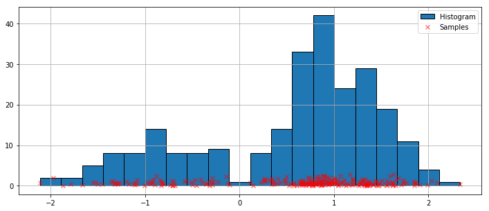

```python
fig = plt.figure(figsize=(12, 5))
ax = fig.add_subplot(111)

# Scatter plot of data samples and histogram
ax.scatter(obs_dist, np.abs(np.random.randn(obs_dist.size)),
            zorder=15, color='red', marker='x', alpha=0.5, label='Samples')
lines = ax.hist(obs_dist, bins=20, edgecolor='k', label='Histogram')

ax.legend(loc='best')
ax.grid(True, zorder=-5)
```

```python
kde = sm.nonparametric.KDEUnivariate(obs_dist)
kde.fit() # Estimate the densities
```

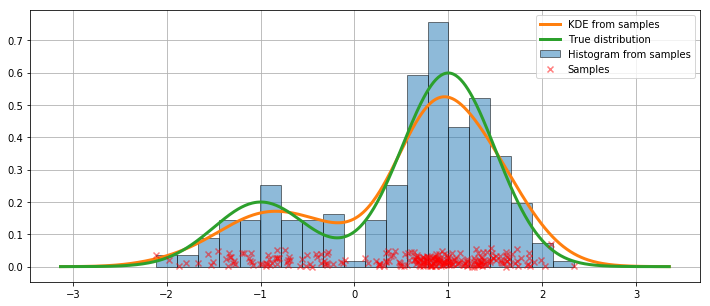

```python
fig = plt.figure(figsize=(12, 5))
ax = fig.add_subplot(111)

# Plot the histrogram
ax.hist(obs_dist, bins=20, density=True, label='Histogram from samples',
        zorder=5, edgecolor='k', alpha=0.5)

# Plot the KDE as fitted using the default arguments
ax.plot(kde.support, kde.density, lw=3, label='KDE from samples', zorder=10)

# Plot the true distribution
true_values = (stats.norm.pdf(loc=dist1_loc, scale=dist1_scale, x=kde.support)*weight1
              + stats.norm.pdf(loc=dist2_loc, scale=dist2_scale, x=kde.support)*weight2)
ax.plot(kde.support, true_values, lw=3, label='True distribution', zorder=15)

# Plot the samples
ax.scatter(obs_dist, np.abs(np.random.randn(obs_dist.size))/40,
           marker='x', color='red', zorder=20, label='Samples', alpha=0.5)

ax.legend(loc='best')
ax.grid(True, zorder=-5)
```

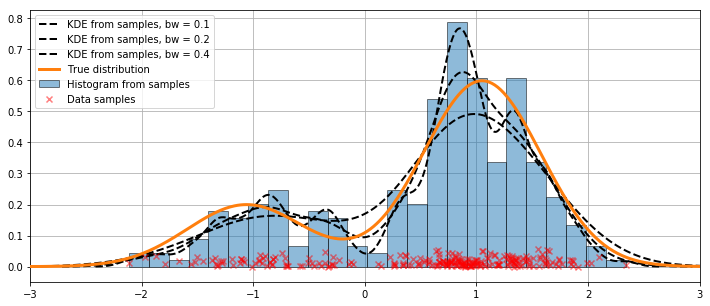

```python
#Varying Bandwidth
fig = plt.figure(figsize=(12, 5))
ax = fig.add_subplot(111)

# Plot the histrogram
ax.hist(obs_dist, bins=25, label='Histogram from samples',
        zorder=5, edgecolor='k', density=True, alpha=0.5)

# Plot the KDE for various bandwidths
for bandwidth in [0.1, 0.2, 0.4]:
    kde.fit(bw=bandwidth) # Estimate the densities
    ax.plot(kde.support, kde.density, '--', lw=2, color='k', zorder=10,
            label='KDE from samples, bw = {}'.format(round(bandwidth, 2)))

# Plot the true distribution
ax.plot(kde.support, true_values, lw=3, label='True distribution', zorder=15)

# Plot the samples
ax.scatter(obs_dist, np.abs(np.random.randn(obs_dist.size))/50,
           marker='x', color='red', zorder=20, label='Data samples', alpha=0.5)

ax.legend(loc='best')
ax.set_xlim([-3, 3])
ax.grid(True, zorder=-5)
```